# Bellabeat Case Study Slideshow

## by Odafe-Ighele Jesse

## Investigation Overview

> The key insights answer the following questions;
> - Do users get off their beds quickly?
> - What Time of the Day are Users the most active?
> - What is the relationship between the calories and total steps?
> - Which day of the week are users the most active?
> - How do users spend their time?
> - Which BMI class covers the most distance and steps?

## Dataset Overview

- Today I'm going to analyze data of Bellabeat, a high-tech manufacturer of health-focused products for women. I followed total six steps: Ask, Prepare, Process, Analyze, Share & Act in following analysis. I used Python to analyze data and spreadsheet program (Microsoft Excel) to visualize data.
- I used 6 datasets provided by Bellabeat. The 6 datasets used different metrics to account for a User's activity such as Total steps, Total Distance, Calories, Heartrate ,etc.

## Do users get off their beds quickly?

The distribution is right skewed hinting that the users are generally fast in getting off their beds

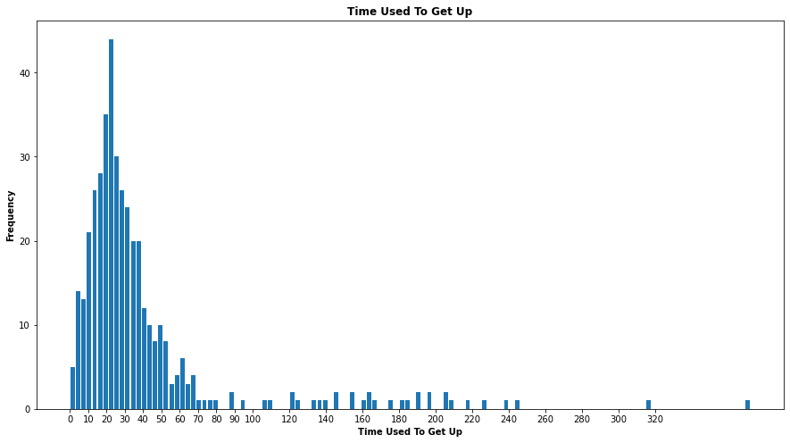

## What Time of the Day are Users the most active?

From the plot above we can see users are the most active in the afternoon with their activity peaking around 18:00 and the least active around 04:00

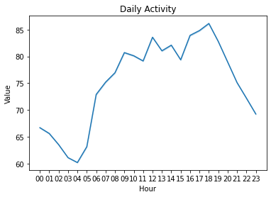

## What is the relationship between the calories and total steps?

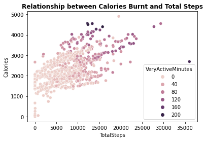

## Which day of the week are users the most active?

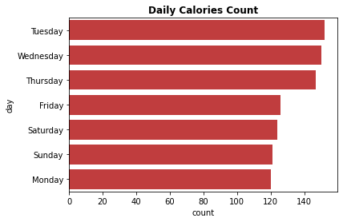

## How do users spend their time?

Based on the donut chart,81% of the time Bellabeat users are sedentary (projected to take less than 5000 steps a day)while only 2% of the time Bellabeat users are very active(projected to take more than 10000 steps a day)

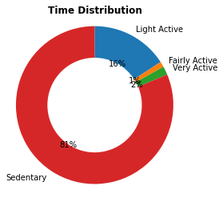

## Step Class Distribution

The Very Active Users are the least users while the sedentary and lightly active users(< 7500 steps per day users) are a combined 64% of the total users

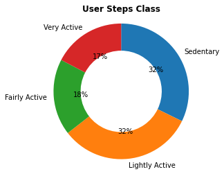

## Which BMI class covers the most distance and steps?

The above visualisations show the BMI class against the average distance covered and the average steps and shows that the users who were overweight have taken the most steps(~14000 steps) and covered the most distance but the women who are obesed have taken by far the least steps(<2000 steps) and covered the least distance as expected

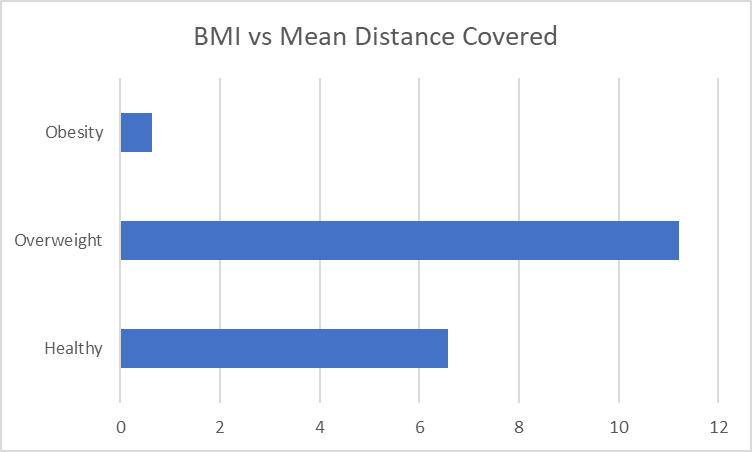

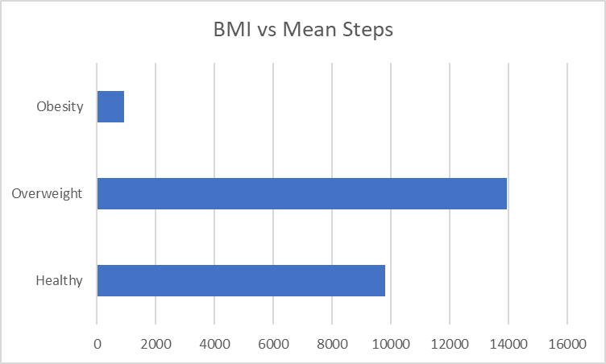

## Conclusion

These are the recommended steps of action to take to improve the Bellabeat user experience:

- Introduction of Target Steps plans in order to reduce the percentage of the sedentary minutes,it basically involves having different plans each categorised based on the amount of calories intended to be burnt per day and formulating the amount of steps required to attain that calories loss
- Daily notifications to remind users to take their targeted steps per day because from the viz we can see despite the encouraging numbers from the Overweight BMI class, the obesed women numbers arent really encouraging so constantly encouraging them to take an adequate number of steps can go a long way
- Daily health tips can also be beneficial to Bellabeat users and can go a long way in improving their heart rates